# Math 490 HW #6

Maxwell Levin

February 6, 2018

## Question 1.

The probability density function $\small{f(x)}$ of the r.v. $\small{X}$ is given by

$$f(x) = \left\{
\begin{array}{ll}
\frac{1}{x^2} & \quad x \geq 1 \\
0 & \quad \text{otherwise.}
\end{array}
\right.$$

#### a. Show that $\small{\int_1^\infty f(x)dx = 1.}$

Since $\small{f(x) = 0}$ when $\small{x < 1}$, our integral becomes

$$\int_1^\infty \frac{1}{x^2} dx.$$

To evaluate this, we take the limit:

$$\lim_{k\to\infty} \int_1^k \frac{1}{x^2}dx,$$
$$\lim_{k\to\infty} \left(-\frac{1}{x}\right) \Big{|}_1^k,$$
$$\lim_{k\to\infty} \left(-\frac{1}{k} - \frac{-1}{1}\right) = 1.$$

#### b. Show that $\small{E(X)}$ does not exist.

We know by definition that

$$E(X) = \int_\infty^\infty x f(x) dx.$$

Since $\small{f(x) = 0}$ when $\small{ x < 1}$, our integral becomes

$$E(x) = \int_1^\infty \frac{1}{x} dx,$$
$$\lim_{k\to\infty} \int_1^k \frac{1}{x}dx,$$
$$\lim_{k\to\infty} ln(x) \Big{|}_1^k,$$
$$\lim_{k\to\infty} ln(k)$$

which is not defined because the natural log diverges as $\small{k\to\infty}.$

#### c. Find the median (or 0.5-quantile, or 50th percentile) of $\small{X}$.

We seek the median, $\small{m}$, such that

$$\int_1^m xf(x)dx = 0.5.$$

That is,

$$\int_1^m \frac{1}{x}dx,$$
$$ln(x) \Big{|}_1^m.$$

#### d. Find the c.d.f. $\small{F(x)}$ of $\small{X}$.

The c.d.f. of $\small{X}$ is

$$F(x) = \left\{
\begin{array}{ll}
\int_1^x f(t)dt & \quad x \geq 1 \\
0 & \quad \text{otherwise.}
\end{array}
\right.$$

When we simplify we get

$$F(x) = \left\{
\begin{array}{ll}
1 - \frac{1}{x} & \quad x \geq 1 \\
0 & \quad \text{otherwise.}
\end{array}
\right.$$

#### e. Find the inverse $\small{F^{-1}(y)}$ of the c.d.f. $\small{F(x)}$ of $\small{X}$.

We calculate the inverse $\small{F^{-1}(y)}$ of $\small{F(x)}$:

$$y = F(X) = 1 - \frac{1}{x}$$
$$x = (1 - y)^{-1}$$
$$F^{-1}(y) = (1 - y)^{-1}.$$

This is defined for

$$0 \leq y < 1.$$

#### f. Use the CDF Inverse Method to sample 10000 values from $\small{X}$. Then make a histogram (with density on the vertical axis), add the density curve to the histogram, and report the median, the mean, and the standard deviation of the 10000 observed values.

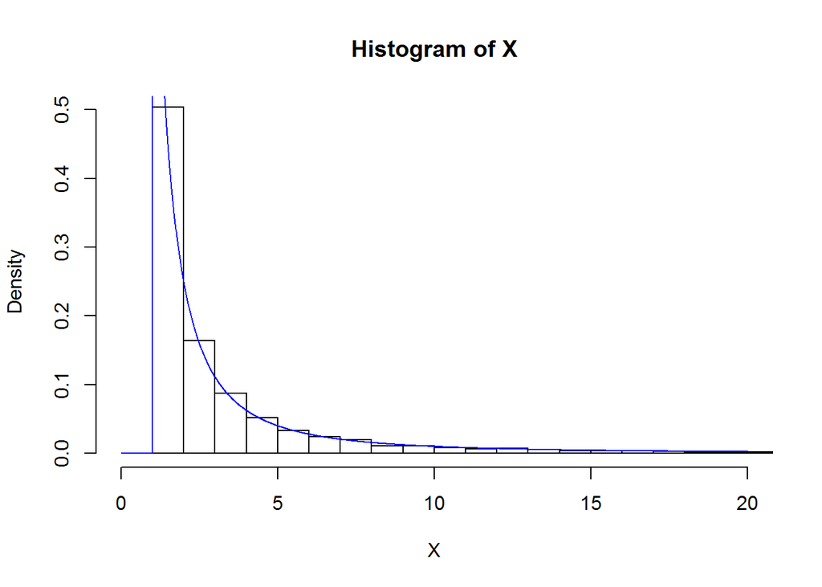

```r
cdfInv = function(n) {
  U = runif(n)
  1 / (1 - U) # result from part (e)
}

X = cdfInv(10000)
hist(X, prob=T, breaks = seq(0, max(X)+1), xlim=c(0,20), ylim=c(0,0.5))

x = seq(0, 20, 0.01)
y = ifelse( x <= 1, 0, 1/x^2)
lines(x, y, col="blue")
```

The median is:

```
     50%
1.982201
```

The mean is:

```
[1] 15.70821
```

The standard deviation is:

```
[1] 509.7905
```